# R Notebook - Benjamin Trampe

Gets current working directory.

```r
getwd()
```

```
[1] "C:/Users/btrampe/Documents/R_Assignment"
```

Create a folder called R_Assignment. Download genotype files called “fang_et_al_genotypes.txt” and “snp_position.txt” Setting working directory to the folder that was just created call R_Assignment.

```r
setwd("~/R_Assignment")
```

A function to install the require the R packages if not already present for the assignment.

```r
installingpackages <- function(x){
  for( i in x ){
    if( ! require( i , character.only = TRUE ) ){
      install.packages( i , dependencies = TRUE)
      require( i , character.only = TRUE )
    }
  }
}
installingpackages( c("tidyr","dplyr","ggplot2" , "reshape2"  ) )
```

Loads all of the require packages.

```r
library(ggplot2)
library(tidyr)
library(plyr)
library(dplyr)
library(reshape2)
```

Loads the text files form the the data frame.

```r
genotype <- as.data.frame(read.table("fang_et_al_genotypes.txt", sep="\t",header=TRUE))
snppos <- as.data.frame(read.table("snp_position.txt", sep="\t",header=TRUE))
```

Gets the file size for each file

```r
file.info("fang_et_al_genotypes.txt")$size
```

```
[1] 11051939
```

```r
file.info("snp_position.txt")$size
```

```
[1] 82763
```

Gives the number of rows in each data frame.

```r
nrow(genotype)
```

```
[1] 2782
```

```r
nrow(snppos)
```

```
[1] 983
```

Gives the number of columns in each data frame.

```r
ncol(genotype)
```

```
[1] 986
```

```r
ncol(snppos)
```

```
[1] 15
```

Gives the structure of the data frame.

```r
str(genotype)
```

```
'data.frame':   2782 obs. of  986 variables:
 $ Sample_ID     : Factor w/ 2782 levels "BKN_001","BKN_002",..: 445 446 442 443 448 450 457 459 460 458 ...
 $ JG_OTU        : Factor w/ 2782 levels "T-aust-1","T-aust-2",..: 1 2 3 4 5 6 7 8 9 10 ...
 $ Group         : Factor w/ 16 levels "TRIPS","ZDIPL",..: 1 1 1 1 1 1 1 1 1 1 ...
 $ abph1.20      : Factor w/ 4 levels "?/?","C/C","C/G",..: 1 1 1 1 1 1 1 1 1 1 ...
 $ abph1.22      : Factor w/ 4 levels "?/?","A/A","A/C",..: 1 1 1 1 1 1 1 1 1 1 ...
 $ ae1.3         : Factor w/ 4 levels "?/?","G/G","G/T",..: 4 4 4 4 4 4 4 4 4 4 ...
 $ ae1.4         : Factor w/ 4 levels "?/?","A/A","A/G",..: 4 1 4 4 4 4 4 4 4 4 ...
 $ ae1.5         : Factor w/ 4 levels "?/?","C/C","C/T",..: 4 4 4 4 4 4 4 4 4 4 ...
 $ an1.4         : Factor w/ 4 levels "?/?","C/C","C/G",..: 2 2 1 2 2 2 2 2 2 2 ...
 $ ba1.6         : Factor w/ 4 levels "?/?","A/A","A/G",..: 1 3 4 4 1 3 4 1 4 1 ...
 $ ba1.9         : Factor w/ 4 levels "?/?","G/G","G/T",..: 2 2 2 2 2 2 2 2 2 2 ...
 $ bt2.5         : Factor w/ 4 levels "?/?","C/C","C/T",..: 1 1 2 2 1 1 1 1 1 1 ...
 $ bt2.7         : Factor w/ 4 levels "?/?","A/A","A/G",..: 2 2 2 2 2 2 2 2 2 2 ...
 $ bt2.8         : Factor w/ 4 levels "?/?","A/A","A/G",..: 1 1 1 1 1 1 1 1 1 1 ...
```

[output cut: 86 more lines]

```r
str(snppos)
```

```
'data.frame':   983 obs. of  15 variables:
 $ SNP_ID              : Factor w/ 983 levels "abph1.20","abph1.22",..: 1 2 3 4 5 6 7 8 9 10 ...
 $ cdv_marker_id       : int  5976 5978 6605 6606 6607 5982 3463 3466 5983 5985 ...
 $ Chromosome          : Factor w/ 12 levels "1","10","2","3",..: 3 3 6 6 6 1 4 4 5 5 ...
 $ Position            : Factor w/ 942 levels "","100227859",..: 624 625 334 333 335 577 396 395 840 842 ...
 $ alt_pos             : Factor w/ 7 levels "","Approximate: 5 prime BLAST start of amplicon plus 150 bases",..: 1 1 1 1 1 1 1 1 1 1 ...
 $ mult_positions      : Factor w/ 18 levels "","Chr1(275076660);Chr8(71078729);",..: 1 1 1 1 1 1 1 1 1 1 ...
 $ amplicon            : Factor w/ 567 levels "abph1","ae1",..: 1 1 2 2 2 3 4 4 5 5 ...
 $ cdv_map_feature.name: Factor w/ 539 levels "AB042260","ae1",..: 1 1 2 2 2 10 443 443 472 472 ...
 $ gene                : Factor w/ 547 levels "abph1","ae1",..: 1 1 2 2 2 10 463 463 472 472 ...
 $ candidate.random    : Factor w/ 2 levels "candidate","random": 1 1 1 1 1 1 1 1 1 1 ...
 $ Genaissance_daa_id  : int  8393 8394 8395 8396 8397 8398 8399 8400 8401 8402 ...
 $ Sequenom_daa_id     : int  10474 10475 10477 10478 10479 10481 10482 10483 10486 10487 ...
 $ count_amplicons     : int  1 0 1 0 0 1 1 0 1 0 ...
 $ count_cmf           : int  1 0 1 0 0 1 0 0 1 0 ...
 $ count_gene          : int  1 0 1 0 0 1 1 0 1 0 ...
```

Sub setting the data to get a data frame for maize and teosinte based on the required groups

```r
maize <- genotype[which(genotype$Group=="ZMMIL" | genotype$Group =="ZMMLR" | genotype$Group == "ZMMMR"),]
teosinte <-genotype[which(genotype$Group=="ZMPBA" | genotype$Group =="ZMPIL" | genotype$Group == "ZMPJA"),]
```

Views the files to verify the correct sub setting was completed

```r
View(maize)
View(teosinte)
```

Sub setting the SNP Position to leave the required data of SNP_ID, Chromosome, and Position

```r
snp_sub <- select(snppos,SNP_ID,Chromosome,Position)
snp_sub$Chromosome[snp_sub$Chromosome == "unknown"] <- NA
snp_sub$Chromosome[snp_sub$Chromosome == "multiple"] <- NA
snp_sub$Position[snp_sub$Position == "unknown"] <- NA
snp_sub$Position[snp_sub$Position == "multiple"] <- NA
View(snp_sub)
```

Removes the Sample_ID,JD_OTU, and Group from the files and transposes the data frame.

```r
maize_rm <- subset(maize, select=-c(Sample_ID,JG_OTU,Group))
t_maize <- as.data.frame(t(maize_rm))
View(t_maize)
teosinte_rm <- subset(teosinte, select=-c(Sample_ID,JG_OTU,Group))
t_teosinte <- as.data.frame(t(teosinte_rm))
```

Combine the SNP File and Gentoype File for Maize and Teosinte.

```r
t_maize <- data.frame(SNP_ID = row.names(t_maize), t_maize)
maize_snp_com <- merge(snp_sub,t_maize,by = "SNP_ID")
t_teosinte <- data.frame(SNP_ID = row.names(t_teosinte), t_teosinte)
teosinte_snp_com <- merge(snp_sub,t_teosinte,by = "SNP_ID")
```

Removes the markers that have unknown or multiple values in the columns of chromosome or position.

```r
maize_snp_fin <- na.omit(maize_snp_com)
teosinte_snp_fin <- na.omit(teosinte_snp_com)
```

Order the positions in ascending order for Maize and Teosinte

```r
incr_maize<-maize_snp_fin[order(as.numeric(as.character(maize_snp_fin$Position))),]
incr_teosinte<-teosinte_snp_fin[order(as.numeric(as.character(teosinte_snp_fin$Position))),]
```

Replaces the ? in the data frame

```r
incr_maize <- as.matrix(incr_maize)
incr_maize[incr_maize=="?/?"]<-"?"
incr_maize <- as.data.frame(incr_maize)
incr_teosinte <- as.matrix(incr_teosinte)
incr_teosinte[incr_teosinte=="?/?"]<-"?"
incr_teosinte <- as.data.frame(incr_teosinte)
```

Writes files for increasing maize

```r
chr<-1:10
for (i in chr){
incr_maize<-incr_maize[incr_maize$Chromosome==i,]
  write.csv(incr_maize,sprintf("Maize_Chr_%d_Increasing",i),row.names = F)
}
```

Writes files for increasing teosinte

```r
chr<-1:10
for (i in chr){
incr_teosinte<-incr_teosinte[incr_teosinte$Chromosome==i,]
  write.csv(incr_teosinte,sprintf("Teosinte_Chr_%d_Increasing",i),row.names = F)
}
```

Order the positions in descending order for Maize and Teosinte

```r
decr_maize<-maize_snp_fin[order(-as.numeric(as.character(maize_snp_fin$Position))),]
decr_teosinte<-teosinte_snp_fin[order(-as.numeric(as.character(teosinte_snp_fin$Position))),]
```

Replaces the ? in the data frame

```r
decr_maize <- as.matrix(decr_maize)
decr_maize[decr_maize=="?/?"]<-"-"
decr_maize <- as.data.frame(decr_maize)
decr_teosinte <- as.matrix(decr_teosinte)
decr_teosinte[decr_teosinte=="?/?"]<-"-"
decr_teosinte <- as.data.frame(decr_teosinte)
```

Writes files for decreasing maize

```r
chr<-1:10
for (i in chr){
decr_maize<-decr_maize[decr_maize$Chromosome==i,]
  write.csv(decr_maize,sprintf("Maize_Chr_%d_Decreasing",i),row.names = F)
}
```

Writes files for decreasing teosinte

```r
chr<-1:10
for (i in chr){
 decr_teosinte<-decr_teosinte[decr_teosinte$Chromosome==i,]
  write.csv(decr_teosinte,sprintf("teosinte_Chr_%d_Decreasing",i),row.names = F)
}
```

Part 2

Plot 1 The graph shows that ZMMLR, ZMPBA, and ZMMIL are the most important groups.

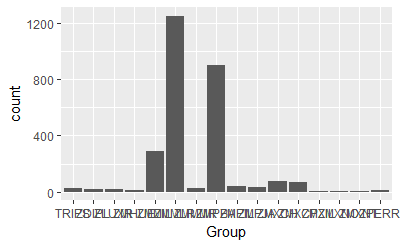

[figure not shown]

```r
genotype_calls$new <- lapply(genotype_calls$Geno_Call,new_geno)
```

```
Error in FUN(X[[i]], ...) : object 'Homo' not found
```

Plots the SNPS on there respective chromosomes.

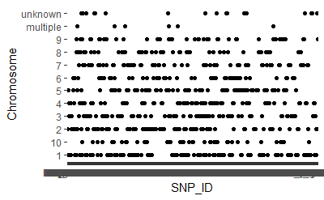